# 📖 Class Imbalance

⚖️ Oversampling

- 🎲 Random Oversampling
- 🧪 SMOTE
- 📈 ADASYN
- 🧊 Borderline SMOTE

📉 Undersampling

- 🎯 Random Undersampling
- 🔗 Tomek Links
- 🧹 ENN
- 📉 NearMiss

🧬 Data Augmentation

- 🧠 Data Augmentation using GANs

⚖️ Class Weighting

- 📊 Logistic Regression Example

⚙️ Algorithm Level Techniques

## Class Imbalance

**📖 Click to Expand**

##### ⚖️ What is Class Imbalance?

Class imbalance occurs when one class significantly outnumbers the other(s). For example, in fraud detection, 98% of transactions may be legitimate while only 2% are fraudulent. This skew can distort model learning.

- Models often learn to favor the majority class
- Overall accuracy may be misleading
- Minority class may be poorly predicted

##### 🌍 Real-World Examples

- Healthcare: predicting rare diseases (e.g., cancer)
- Finance: credit card fraud detection
- Cybersecurity: detecting intrusions or malware
- Customer Success: identifying churned or escalated users

##### 🚧 Challenges with Imbalanced Data

- Accuracy becomes misleading (e.g., always predicting the majority yields high accuracy but zero value)
- Decision boundaries may skew toward the dominant class
- Minority class data often lacks enough variation to generalize

##### 🎯 Why It Matters

- Improves precision and recall for the minority class
- Makes models fairer and more useful in high-risk applications
- Avoids false confidence from inflated accuracy metrics

This notebook covers techniques to address imbalance using oversampling, undersampling, synthetic data generation, and algorithm-level adjustments.

```python
import pandas as pd
import numpy as np

# Set random seed for reproducibility
np.random.seed(42)

# Number of samples
n_samples = 10_000

# Class distribution (98% legitimate, 2% fraudulent)
fraud_ratio = 0.02
legitimate_ratio = 1 - fraud_ratio

# Number of samples per class
n_fraud = int(n_samples * fraud_ratio)
n_legitimate = n_samples - n_fraud

# Generate features
# 1. Transaction Amount (log-normal distribution for skewness)
transaction_amount_legit = np.random.lognormal(mean=3.5, sigma=1, size=n_legitimate)
transaction_amount_fraud = np.random.lognormal(mean=5, sigma=1.5, size=n_fraud)

# 2. Transaction Type (categorical: online, in-person, other)
transaction_type_legit = np.random.choice(['Online', 'In-Person', 'Other'], size=n_legitimate, p=[0.5, 0.4, 0.1])
transaction_type_fraud = np.random.choice(['Online', 'In-Person', 'Other'], size=n_fraud, p=[0.7, 0.2, 0.1])

# 3. Time of Transaction (hour of the day: 0-23)
time_of_transaction_legit = np.random.randint(0, 24, size=n_legitimate)
time_of_transaction_fraud = np.random.randint(0, 24, size=n_fraud)

# Combine data
data = {
    "Transaction_Amount": np.concatenate([transaction_amount_legit, transaction_amount_fraud]),
    "Transaction_Type": np.concatenate([transaction_type_legit, transaction_type_fraud]),
    "Time_of_Transaction": np.concatenate([time_of_transaction_legit, time_of_transaction_fraud]),
    "Class": np.concatenate([np.zeros(n_legitimate), np.ones(n_fraud)]),  # 0: Legitimate, 1: Fraud
}

# Create DataFrame
df = pd.DataFrame(data)

# Shuffle the dataset
df = df.sample(frac=1).reset_index(drop=True)
df.head()
```

|  | Transaction_Amount | Transaction_Type | Time_of_Transaction | Class |
| --- | --- | --- | --- | --- |
| 0 | 16.360820 | In-Person | 3 | 0.0 |
| 1 | 7.728736 | In-Person | 17 | 0.0 |
| 2 | 19.464428 | In-Person | 6 | 0.0 |
| 3 | 1.828955 | Online | 15 | 0.0 |
| 4 | 7.894720 | Online | 10 | 0.0 |

Back to the top

# ⚖️ Oversampling

**📖 Click to Expand**

##### ⚖️ What is Oversampling?

Oversampling is a technique to address class imbalance by increasing the number of samples in the minority class.

- Involves duplicating or synthetically generating minority class examples
- Aims to balance the class distribution without losing any data
- Typically applied **before model training** on the training set only

##### 📌 When to Use

- Severe imbalance causing poor recall or precision
- You want to preserve all majority class data
- You're using models that can handle redundant data (e.g., tree-based models)

##### ⚠️ Cautions

- Risk of **overfitting** if the same samples are duplicated
- Synthetic methods (like SMOTE) can introduce noise or unrealistic data points

Create Datasets

```python
# Install required libraries
# pip install imbalanced-learn scikit-learn

from sklearn.model_selection import train_test_split
from sklearn.datasets import make_classification
import pandas as pd

# Create a toy imbalanced dataset
X, y = make_classification(n_classes=2, class_sep=2,
                           weights=[0.9, 0.1], n_informative=3, n_redundant=1,
                           flip_y=0, n_features=5, n_clusters_per_class=1, n_samples=1000, random_state=42)
print(pd.DataFrame(X))
print(y)

# Visualize original class distribution
print(pd.Series(y).value_counts())
```

```
            0         1         2         3         4
0    1.021519 -0.548166 -2.079610  2.988799 -2.282637
1    0.210297  0.378811 -1.558116  1.737750 -2.083806
2    0.312219  0.266673 -0.873507  2.422799 -2.373239
3    0.613577 -0.487993 -1.824985  2.346751 -2.172025
4   -0.062001 -0.837709 -1.414938  1.124668 -1.826684
..        ...       ...       ...       ...       ...
995  0.141158  1.410214 -2.320817  0.749351 -1.453040
996  0.580855  0.286195 -2.667136  1.670716 -1.840654
997  0.769980 -1.460925 -3.103829  1.648837 -1.679590
998  1.133483  0.553364 -3.761090  1.939160 -1.648539
999  0.457990 -2.664332 -0.959610  2.629161 -2.386679

[1000 rows x 5 columns]
[0 0 0 0 0 0 0 0 0 0 0 0 0 0 0 0 0 0 1 0 0 0 0 0 0 0 0 0 0 0 0 0 1 1 1 0 0
```

[output cut: 30 more lines]

Define Functions - Plot Before vs After

```python
import matplotlib.pyplot as plt
import numpy as np

# Function to visualize before and after resampling
def plot_before_after(X_before, y_before, X_after, y_after, technique_name, feature_names=None):
    """
    Plots before and after resampling for a dataset.

    Parameters:
        X_before (array): Original feature data before resampling.
        y_before (array): Target labels before resampling.
        X_after (array): Feature data after resampling.
        y_after (array): Target labels after resampling.
        technique_name (str): Name of the resampling technique.
        feature_names (list or None): Feature names for x-axis and y-axis labels. Should be a list like ['Feature 1', 'Feature 2'].
    """
    fig, axes = plt.subplots(1, 2, figsize=(14, 6), sharex=True, sharey=True)

    # Set feature names for axes
    x_label = feature_names[0] if feature_names else 'Feature 1'
    y_label = feature_names[1] if feature_names else 'Feature 2'

    # Get unique labels dynamically for legends
    labels_before = np.unique(y_before)
    labels_after = np.unique(y_after)

    # Before Resampling
    for label in labels_before:
        axes[0].scatter(X_before[y_before == label][:, 0], X_before[y_before == label][:, 1],
                        label=f'Class {label}', alpha=0.7)
    axes[0].set_title(f"Before Resampling ({technique_name})")
    axes[0].set_xlabel(x_label)
    axes[0].set_ylabel(y_label)
    axes[0].legend()
    axes[0].grid(True)

    # After Resampling
    for label in labels_after:
        axes[1].scatter(X_after[y_after == label][:, 0], X_after[y_after == label][:, 1],
                        label=f'Class {label}', alpha=0.7)
    axes[1].set_title(f"After Resampling ({technique_name})")
    axes[1].set_xlabel(x_label)
    axes[1].set_ylabel(y_label)
    axes[1].legend()
    axes[1].grid(True)

    # Adjust layout
    plt.tight_layout()
    plt.show()
```

#### 🎲 Random Oversampling

**📖 Click to Expand**

##### 🎲 What is Random Oversampling?

Random Oversampling duplicates existing minority class samples until class balance is achieved.

- Simple and fast to implement
- No synthetic data — just replication
- Often used as a baseline technique

##### ⚠️ Limitations

- High risk of **overfitting** to duplicated samples
- No increase in data diversity

```python
# !pip uninstall -y imbalanced-learn scikit-learn
# !pip install scikit-learn==1.2.2
# !pip install imbalanced-learn==0.10.1

# Random Oversampling
from imblearn.over_sampling import RandomOverSampler
ros = RandomOverSampler(random_state=42)
X_resampled, y_resampled = ros.fit_resample(X, y)

# Check new class distribution
print(pd.Series(y_resampled).value_counts())
```

```
0    900
1    900
dtype: int64
```

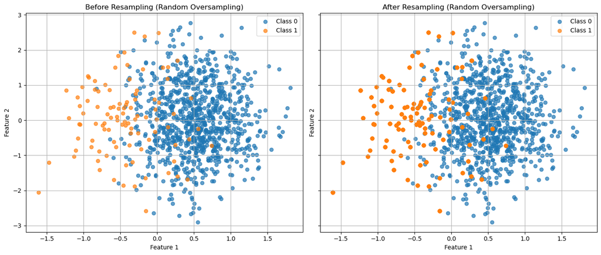

```python
plot_before_after(X, y, X_resampled, y_resampled, "Random Oversampling")
```

#### 🧪 SMOTE

**📖 Click to Expand**

##### 🧪 What is SMOTE?

SMOTE (Synthetic Minority Over-sampling Technique) generates new, synthetic minority class samples by interpolating between existing ones.

- Increases minority class diversity
- Reduces overfitting compared to random duplication
- Widely used in practice

##### ⚠️ Limitations

- Can create overlapping between classes if not used carefully
- Sensitive to noise and outliers in the minority class
- Not ideal for high-dimensional or categorical data without adaptation

```python
# SMOTE
from imblearn.over_sampling import SMOTE
smote = SMOTE(random_state=42)
X_resampled_smote, y_resampled_smote = smote.fit_resample(X, y)

# Check new class distribution
print(pd.Series(y_resampled_smote).value_counts())
```

```
0    900
1    900
dtype: int64
```

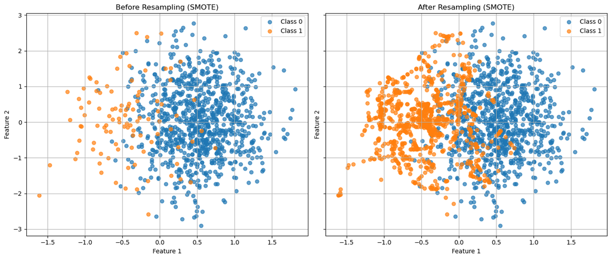

```python
plot_before_after(X, y, X_resampled_smote, y_resampled_smote, "SMOTE")
```

#### 📈 ADASYN

**📖 Click to Expand**

##### 📈 What is ADASYN?

ADASYN (Adaptive Synthetic Sampling) is a SMOTE variant that focuses on generating more synthetic samples in **hard-to-learn** minority regions.

- Adapts sampling density based on local data difficulty
- Prioritizes borderline or sparsely represented areas
- Encourages better model learning near class boundaries

##### ⚠️ Limitations

- Can amplify noise if minority class is poorly defined
- Adds complexity compared to SMOTE
- May shift decision boundaries unexpectedly

```python
# ADASYN
from imblearn.over_sampling import ADASYN
adasyn = ADASYN(random_state=42)
X_resampled_adasyn, y_resampled_adasyn = adasyn.fit_resample(X, y)

# Check new class distribution
print(pd.Series(y_resampled_adasyn).value_counts())
```

```
0    900
1    900
dtype: int64
```

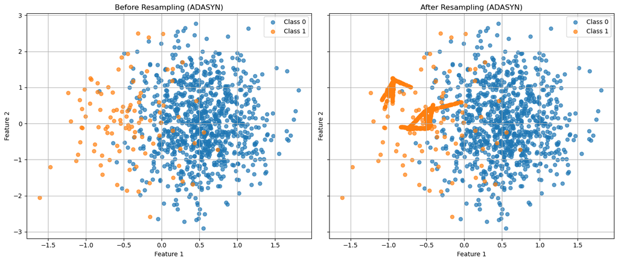

```python
plot_before_after(X, y, X_resampled_adasyn, y_resampled_adasyn, "ADASYN")
```

#### 🧊 Borderline SMOTE

**📖 Click to Expand**

##### 🧊 What is Borderline SMOTE?

Borderline SMOTE generates synthetic samples **only for minority class points near the decision boundary**, where misclassification risk is highest.

- Focuses on ambiguous regions between classes
- Improves classifier sensitivity at the boundary
- Less likely to oversample safe or noisy regions

##### ⚠️ Limitations

- Still assumes meaningful interpolation in feature space
- Not suitable if boundary regions are heavily noisy or mislabeled

```python
# Borderline-SMOTE
from imblearn.over_sampling import BorderlineSMOTE
borderline_smote = BorderlineSMOTE(kind='borderline-1', random_state=42)
X_resampled_borderline, y_resampled_borderline = borderline_smote.fit_resample(X, y)

# Check new class distribution
print(pd.Series(y_resampled_borderline).value_counts())
```

```
0    900
1    900
dtype: int64
```

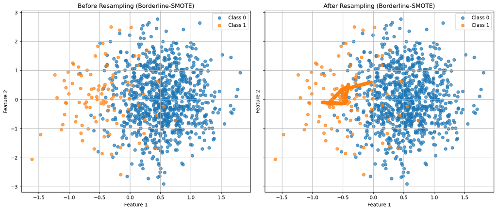

```python
plot_before_after(X, y, X_resampled_borderline, y_resampled_borderline, "Borderline-SMOTE")
```

Back to the top

# 📉 Undersampling

**📖 Click to Expand**

##### 📉 What is Undersampling?

Undersampling reduces the number of majority class samples to balance class distribution.

- Works by removing redundant or less informative majority class data
- Helps speed up training and reduces memory usage
- Often paired with ensemble methods to preserve performance

##### 📌 When to Use

- Abundant majority class data that’s easy to trim
- Class imbalance is mild-to-moderate
- When model overfitting to the majority class is a concern

##### ⚠️ Limitations

- Risk of **losing valuable information**
- May lead to underperforming models if informative samples are discarded

Create Datasets

```python
# Install required libraries
# pip install imbalanced-learn scikit-learn pandas matplotlib

from sklearn.datasets import make_classification
import pandas as pd

# Create a toy imbalanced dataset
X, y = make_classification(n_classes=2, class_sep=2,
                           weights=[0.9, 0.1], n_informative=3, n_redundant=1,
                           flip_y=0, n_features=5, n_clusters_per_class=1, n_samples=1000, random_state=42)

# Convert to DataFrame for better visualization
df_X = pd.DataFrame(X, columns=[f"Feature_{i+1}" for i in range(X.shape[1])])
df_y = pd.Series(y, name="Target")

# Visualize class distribution
print("Original Class Distribution:")
print(df_y.value_counts())
```

```
Original Class Distribution:
0    900
1    100
Name: Target, dtype: int64
```

#### 🎯 Random Undersampling

**📖 Click to Expand**

##### 🎯 What is Random Undersampling?

Random Undersampling removes a subset of majority class samples at random to balance the dataset.

- Very easy to implement
- Reduces training time and memory usage
- Often used as a quick baseline method

##### ⚠️ Limitations

- Can discard **informative majority samples**
- May lead to **underfitting** or unstable models if too aggressive

```python
from imblearn.under_sampling import RandomUnderSampler

# Random Undersampling
rus = RandomUnderSampler(random_state=42)
X_resampled_rus, y_resampled_rus = rus.fit_resample(X, y)

# Visualize resampled class distribution
print("Random Undersampling Class Distribution:")
print(pd.Series(y_resampled_rus).value_counts())
```

```
Random Undersampling Class Distribution:
0    100
1    100
dtype: int64
```

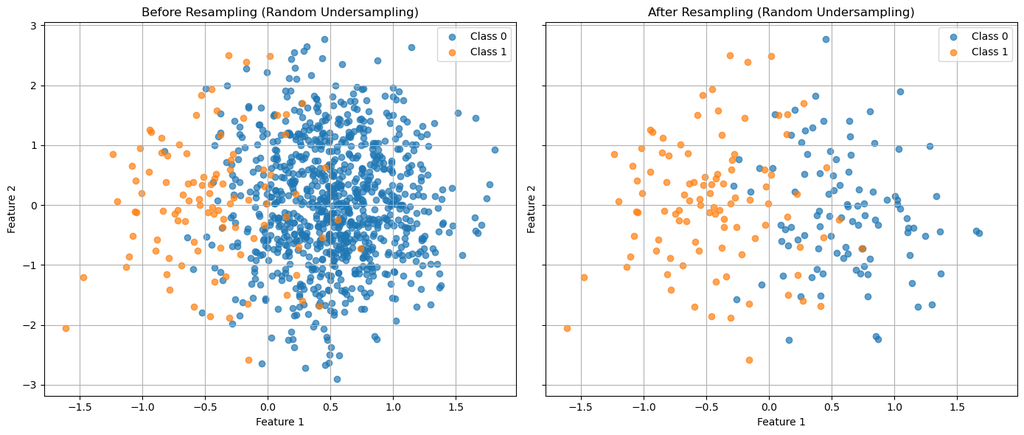

```python
# Plot before and after
plot_before_after(X, y, X_resampled_rus, y_resampled_rus, "Random Undersampling")
```

#### 🔗 Tomek Links

**📖 Click to Expand**

##### 🔗 What are Tomek Links?

A Tomek Link is a pair of samples from **opposite classes** that are each other’s nearest neighbors. Removing the majority class sample in each pair helps clean the class boundary.

- Used to **reduce class overlap**
- Improves boundary clarity between classes
- Often combined with undersampling or SMOTE

##### ⚠️ Limitations

- Only removes borderline points — not sufficient alone for severe imbalance
- Assumes Euclidean distance is meaningful for proximity

```
Tomek Links Class Distribution:
0    900
1    100
dtype: int64
```

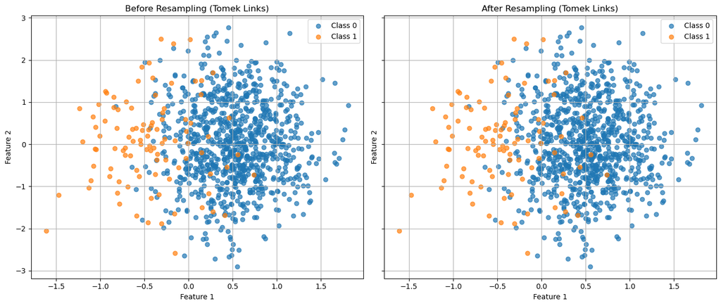

```python
from imblearn.under_sampling import TomekLinks

# Tomek Links
tomek = TomekLinks()
X_resampled_tomek, y_resampled_tomek = tomek.fit_resample(X, y)

# Visualize resampled class distribution
print("Tomek Links Class Distribution:")
print(pd.Series(y_resampled_tomek).value_counts())
plot_before_after(X, y, X_resampled_tomek, y_resampled_tomek, "Tomek Links")
```

#### 🧹 ENN

**📖 Click to Expand**

##### 🧹 What is ENN?

Edited Nearest Neighbors (ENN) removes majority class samples that are **misclassified by their nearest neighbors**.

- Acts as a **data cleaning filter**
- Helps refine noisy or overlapping class boundaries
- Can improve classifier generalization

##### ⚠️ Limitations

- May remove too many samples if class boundaries are unclear
- Sensitive to the choice of `k` (number of neighbors)

```
Edited Nearest Neighbors Class Distribution:
0    899
1    100
dtype: int64
```

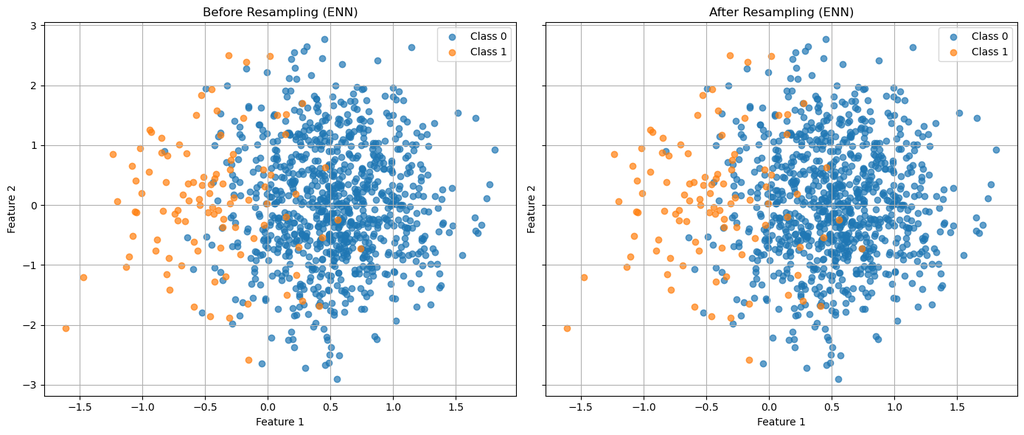

```python
from imblearn.under_sampling import EditedNearestNeighbours

# Edited Nearest Neighbors (ENN)
enn = EditedNearestNeighbours(n_neighbors=3)
X_resampled_enn, y_resampled_enn = enn.fit_resample(X, y)

# Visualize resampled class distribution
print("Edited Nearest Neighbors Class Distribution:")
print(pd.Series(y_resampled_enn).value_counts())

plot_before_after(X, y, X_resampled_enn, y_resampled_enn, "ENN")
```

#### 📉 NearMiss

**📖 Click to Expand**

##### 📉 What is NearMiss?

NearMiss is an undersampling technique that selects majority class samples **closest to the minority class** based on distance.

- Retains majority samples near the decision boundary
- Focuses learning on **challenging cases**
- Comes in different variants (NearMiss-1, 2, 3) depending on how distances are computed

##### ⚠️ Limitations

- Can discard important global patterns in the majority class
- Sensitive to noisy or overlapping data

```
NearMiss Class Distribution:
0    100
1    100
dtype: int64
```

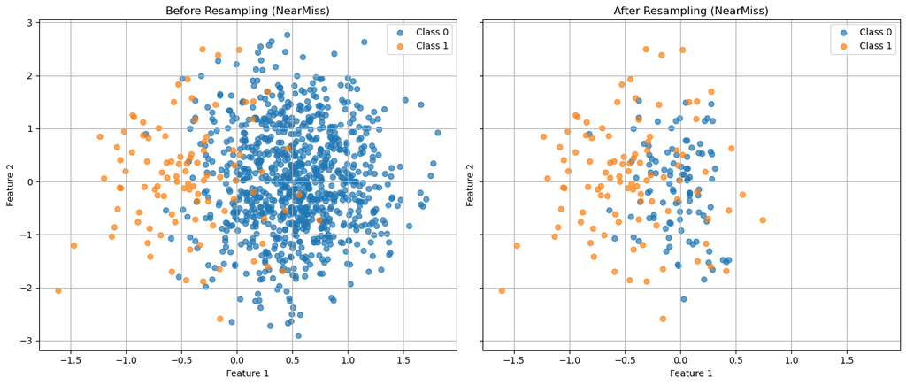

```python
from imblearn.under_sampling import NearMiss

# NearMiss (Version 1)
nearmiss = NearMiss(version=1)
X_resampled_nearmiss, y_resampled_nearmiss = nearmiss.fit_resample(X, y)

# Visualize resampled class distribution
print("NearMiss Class Distribution:")
print(pd.Series(y_resampled_nearmiss).value_counts())

plot_before_after(X, y, X_resampled_nearmiss, y_resampled_nearmiss, "NearMiss")
```

Back to the top

# 🧬 Data Augmentation

**📖 Click to Expand**

##### 🧬 What is Data Augmentation?

Data augmentation involves creating new synthetic samples to enrich the dataset, especially the minority class.

- Helps **boost sample diversity** without collecting new data
- Often used when oversampling alone is insufficient
- Techniques range from simple noise injection to generative models like GANs

##### 📌 Benefits

- Improves model robustness
- Reduces overfitting on limited minority examples
- Encourages better generalization in real-world settings

#### 🧠 Data Augmentation using GANs

**📖 Click to Expand**

##### 🧠 What is GAN-based Augmentation?

Generative Adversarial Networks (GANs) can be used to create **high-fidelity synthetic samples** for the minority class.

- A GAN learns the data distribution and generates new, realistic examples
- Particularly useful for image, text, or structured data where diversity matters
- Helps capture **nonlinear patterns** that simpler methods miss

##### ⚠️ Limitations

- Requires significant training time and tuning
- Risk of generating unrealistic or mode-collapsed samples
- Needs careful validation to avoid injecting noise

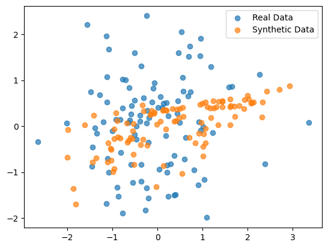

```python
import tensorflow as tf
from tensorflow.keras import layers
import numpy as np
import matplotlib.pyplot as plt

# Generate synthetic 2D real data
def create_real_data(n_samples=100):
    X1 = np.random.normal(loc=0.0, scale=1.0, size=(n_samples, 1))
    X2 = np.random.normal(loc=0.0, scale=1.0, size=(n_samples, 1))
    return np.hstack((X1, X2))

real_data = create_real_data(100)

# Define Generator
def build_generator(latent_dim, output_dim):
    model = tf.keras.Sequential([
        layers.Dense(16, activation='relu', input_dim=latent_dim),
        layers.Dense(output_dim, activation='linear')
    ])
    return model

# Define Discriminator
def build_discriminator(input_dim):
    model = tf.keras.Sequential([
        layers.Dense(16, activation='relu', input_dim=input_dim),
        layers.Dense(1, activation='sigmoid')
    ])
    return model

# Instantiate models
latent_dim = 2
generator = build_generator(latent_dim=latent_dim, output_dim=2)
discriminator = build_discriminator(input_dim=2)

# Optimizers
generator_optimizer = tf.keras.optimizers.Adam(learning_rate=0.001)
discriminator_optimizer = tf.keras.optimizers.Adam(learning_rate=0.001)

# Loss function
cross_entropy = tf.keras.losses.BinaryCrossentropy(from_logits=False)

# Training step
@tf.function
def train_step(real_data):
    # Convert real_data to float32 for compatibility
    real_data = tf.cast(real_data, tf.float32)
    batch_size = real_data.shape[0]

    # Generate fake data
    noise = tf.random.normal([batch_size, latent_dim])
    generated_data = generator(noise, training=True)

    # Combine real and fake data
    combined_data = tf.concat([real_data, generated_data], axis=0)
    labels = tf.concat([tf.ones((batch_size, 1)), tf.zeros((batch_size, 1))], axis=0)

    # Add noise to labels for stability
    labels += 0.05 * tf.random.uniform(labels.shape)

    # Train discriminator
    with tf.GradientTape() as disc_tape:
        predictions = discriminator(combined_data, training=True)
        disc_loss = cross_entropy(labels, predictions)
    gradients_of_discriminator = disc_tape.gradient(disc_loss, discriminator.trainable_variables)
    discriminator_optimizer.apply_gradients(zip(gradients_of_discriminator, discriminator.trainable_variables))

    # Train generator
    noise = tf.random.normal([batch_size, latent_dim])
    misleading_labels = tf.ones((batch_size, 1))  # Labels trick discriminator into thinking generated data is real
    with tf.GradientTape() as gen_tape:
        generated_data = generator(noise, training=True)
        predictions = discriminator(generated_data, training=True)
        gen_loss = cross_entropy(misleading_labels, predictions)
    gradients_of_generator = gen_tape.gradient(gen_loss, generator.trainable_variables)
    generator_optimizer.apply_gradients(zip(gradients_of_generator, generator.trainable_variables))

    return disc_loss, gen_loss

# GAN training loop
def train_gan(generator, discriminator, real_data, epochs=1000):
    for epoch in range(epochs):
        disc_loss, gen_loss = train_step(real_data)
        if epoch % 100 == 0:
            print(f"Epoch {epoch}/{epochs}, Discriminator Loss: {disc_loss:.4f}, Generator Loss: {gen_loss:.4f}")

# Train GAN
train_gan(generator, discriminator, real_data, epochs=1000)

# Generate synthetic data
noise = tf.random.normal([100, latent_dim])
synthetic_data = generator(noise, training=False)

# Visualize real and synthetic data
plt.scatter(real_data[:, 0], real_data[:, 1], label="Real Data", alpha=0.7)
plt.scatter(synthetic_data[:, 0], synthetic_data[:, 1], label="Synthetic Data", alpha=0.7)
plt.legend()
plt.show()
```

Back to the top

# ⚖️ Class Weighting

**📖 Click to Expand**

##### ⚖️ What is Class Weighting?

Class weighting assigns **higher penalty to errors** on the minority class during training, guiding the model to pay more attention to underrepresented outcomes.

- Implemented via `class_weight='balanced'` in many ML libraries
- Adjusts the loss function without modifying the data
- Especially useful for models like logistic regression, SVMs, and neural networks

##### 📌 When to Use

- When resampling isn’t feasible or effective
- When the algorithm natively supports weighted loss
- To avoid modifying data distribution through oversampling/undersampling

#### 📊 Logistic Regression Example

```python
from sklearn.datasets import make_classification
from sklearn.model_selection import train_test_split
from sklearn.linear_model import LogisticRegression
from sklearn.metrics import classification_report
from sklearn.utils.class_weight import compute_class_weight
import numpy as np

# Generate an imbalanced dataset
X, y = make_classification(n_classes=2, class_sep=2,
                           weights=[0.9, 0.1], n_informative=3, n_redundant=1,
                           flip_y=0, n_features=5, n_clusters_per_class=1, n_samples=1000, random_state=42)

# Split dataset into training and test sets
X_train, X_test, y_train, y_test = train_test_split(X, y, test_size=0.3, random_state=42)

# Calculate class weights
class_weights = compute_class_weight(class_weight='balanced', classes=np.unique(y), y=y_train)
class_weight_dict = dict(enumerate(class_weights))

print("Class Weights:", class_weight_dict)

# Train a Logistic Regression model with class weights
model = LogisticRegression(class_weight=class_weight_dict, random_state=42)
model.fit(X_train, y_train)

# Evaluate the model
y_pred = model.predict(X_test)
print(classification_report(y_test, y_pred))
```

```
Class Weights: {0: 0.5564387917329093, 1: 4.929577464788732}
              precision    recall  f1-score   support

           0       1.00      1.00      1.00       271
           1       1.00      1.00      1.00        29

    accuracy                           1.00       300
   macro avg       1.00      1.00      1.00       300
weighted avg       1.00      1.00      1.00       300
```

Back to the top

# ⚙️ Algorithm Level Techniques

**📖 Click to Expand**

##### ⚙️ What Are Algorithm-Level Techniques?

Algorithm-level techniques address class imbalance **within the learning algorithm itself**, without altering the data.

##### 🔧 Cost-Sensitive Learning

- Modifies the loss function to assign higher penalties to misclassified minority class samples
- Common in logistic regression, SVMs, and neural networks via `class_weight` or custom loss

##### 🧠 Ensemble Approaches

- Use internal balancing or adaptive weighting to improve minority class performance
- Examples:
  - **Balanced Random Forest**: samples each tree’s data to be class-balanced
  - **EasyEnsemble**: trains multiple models on balanced subsets and combines predictions
  - **Boosting with Class Weights**: supported in XGBoost, LightGBM, CatBoost

Back to the top